# Filtering, mapping and plotting LiPD objects

Nick McKay

2020-09-16

#LiPD filtering and mappings

```r
library(lipdR)
library(geoChronR)
library(ggplot2)
library(tidyverse)
```

First let’s load some data

```r
iso <- readLipd("http://lipdverse.org/iso2k/1_0_0/iso2k1_0_0.zip")
```

To quickly map a bunch of LiPD files, use `mapLipd()`

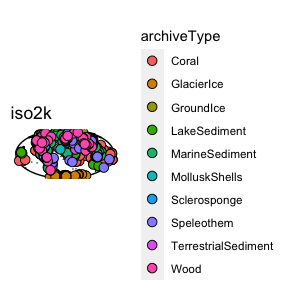

```r
mapLipd(iso, global = TRUE,size = 3) + ggtitle("iso2k")
```

Now we’ve seen an overview of all the files we’ve loaded, but now we’d like to filter the data.

First, we’ll extract a TS object, the primary way to work with multiple LiPD files. A TS is a list object that has an entry for each, column, and is readily queryable.

```r
TS <- extractTs(iso)
```

Now we’ll filter it based on a range of criteria. For simple filtering, that include queries like `>` `<` or `==`, you can use `filterTs`

```r
iTS <- filterTs(TS, "paleoData_iso2kPrimaryTimeseries == TRUE")
```

```
## [1] "606 results after query: paleoData_iso2kPrimaryTimeseries == TRUE"
```

For more complex queries, however, it’s often more efficient to pull vectors of the metadata that you’d like to query and build and index

```r
lat <- pullTsVariable(iTS,"geo_latitude")
lon <- pullTsVariable(iTS,"geo_longitude")
var.name <- pullTsVariable(iTS,"paleoData_variableName")

index <- which(between(lat,10,50) & between (lon,70,170) & var.name == "d18O")

gTS <- iTS[index]
```

OK, now we’ve filtered down to what we’d like to map. We can use `mapTs()` to map this.

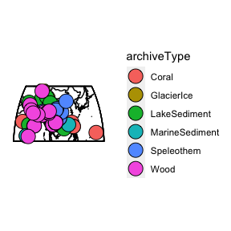

```r
mapTs(gTS)
```

You can change the mapping options by passing options to `basemap()` which creates the base map. Try `?basemap` for options.

##Time availability

You can also quickly make a plot of availability through time:

[output not shown]

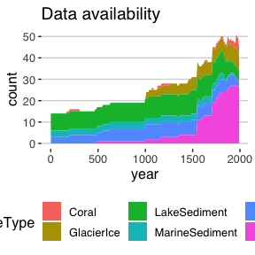

```r
plotTimeAvailabilityTs(gTS,age.range = c(1,2000),age.var = "year")
```

Finally, if you just want a quick overview, `summaryPlotTs()` will quickly combine these two plots, but with fewer options

[output not shown]

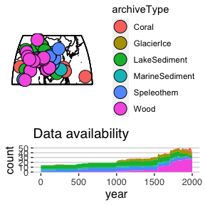

```r
summaryPlotTs(gTS,age.var = "year", age.range = c(0,2000))
```